# Student Ethogram - Data Analysis

Marinara Marcato

## Introduction

This document shows the data analysis carried out to investigate dog’s behavioral data considering the ethograms filled out by students Hazel and Conghal.

## Data Exploration

### Columns: Variables

The ethogram comprised of the following types and number of variables.

```
## Ordinal: 39
```

```
## Count: 7
```

```
## Categorical: 13
```

```
## All: 59
```

### Rows: Dogs

Total number of ethograms in the dataset:

```
## 114
```

Total number of ethograms for each Data Collection:

```
## DC1: 52
##  Diva,Douglas,Dugg,Earl,Ebbi,Edrick,Effie,Eldin,Elf,Eliza,Emmy,Esme,Evie,Fargo,Fawn,Fergus,Flora,Gav,Gilli,Goober,Gretel,Harmony,Harry,Harvey,Hayley,Herbie,Hollie,Idris,Illana,Irrie,Jane,Jazzi,Jessie,Jira,Jojo,Josie,Joy,Judson,July,Junior,Kacie,Kain,Kaiser,Kali,Katie,Kelvin,Kirby,Mac,Mara,Meg,Mil…
```

```
## DC2: 42
##  Douglas,Dugg,Earl,Ebbi,Edrick,Effie,Eldin,Elf,Eliza,Emmy,Evie,Fargo,Fawn,Flora,Gav,Goober,Gretel,Harmony,Harry,Harvey,Hayley,Herbie,Idris,Irrie,Jane,Jazzi,Jessie,Jira,Jojo,Josie,Joy,Judson,July,Junior,Kacie,Kain,Kaiser,Katie,Kelvin,Kirby,Meeko,Meg
```

[output not shown]

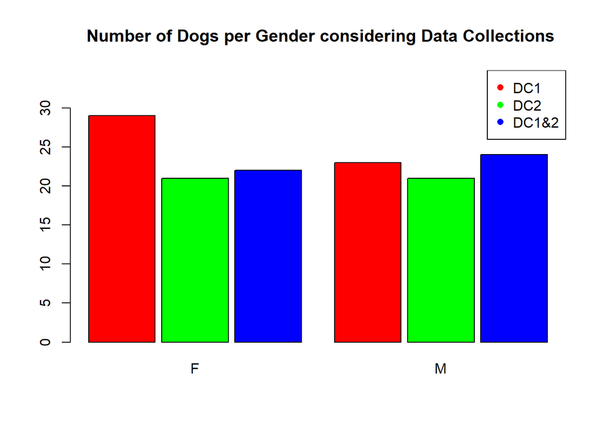

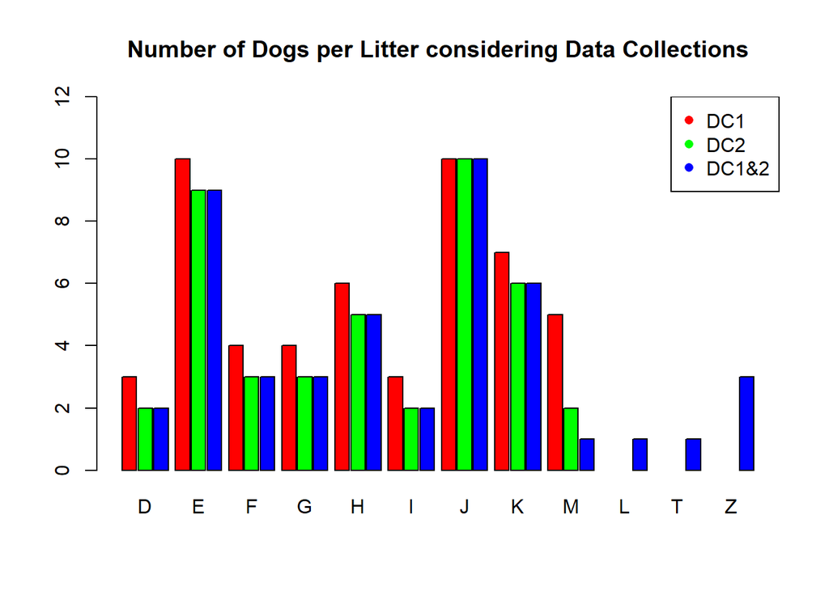

## Data Analysis

### Between Litters, Controlling for DC

The difference in behaviours between different Litters will be investigated controlling for Data Collection.

##### Ordinal Variables

```
## DC 1 - Difference between litters
```

```
##                                                       statistic parameter
## [1,] "Familiarisation.Response..Oriented.to.Handler." 17.91558  8
## [2,] "Distractions.First.Response..Object."           17.10929  8
## [3,] "Kong.Concentration.Response"                    21.59661  8
## [4,] "Crate.Behaviours..Attention.Seeking."           15.84638  8
##      p.value
## [1,] 0.02186841
## [2,] 0.02899095
## [3,] 0.005720592
## [4,] 0.04463235
```

```
## DC 2 - Difference between litters
```

```
##                                   statistic parameter p.value
## [1,] "Walking.Distractibility"    21.48013  8         0.005975649
## [2,] "Walking.Initiative"         15.87624  8         0.04418608
## [3,] "Distractions.Pull.strength" 15.91063  8         0.04367721
```

```
## [1] "Familiarisation.Response..Oriented.to.Handler."
```

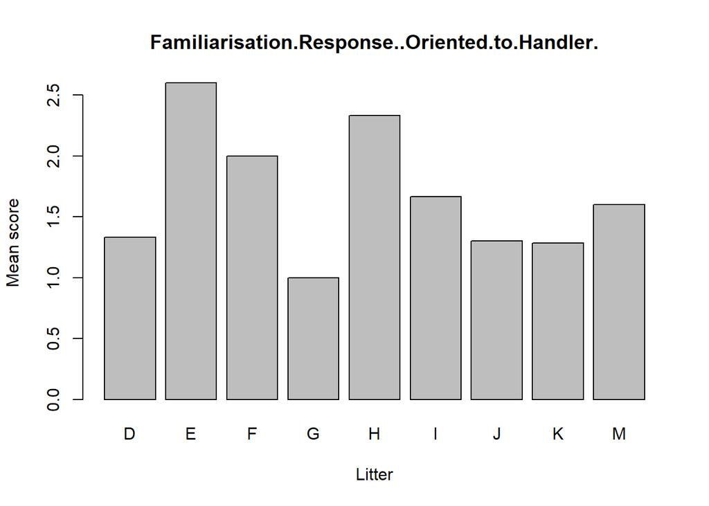

```
## [1] "Distractions.First.Response..Object."
```

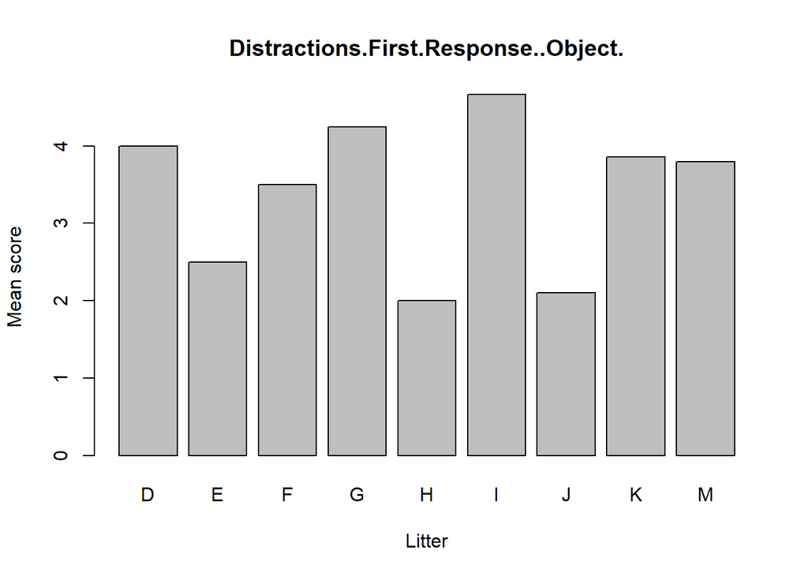

```
## [1] "Kong.Concentration.Response"
```

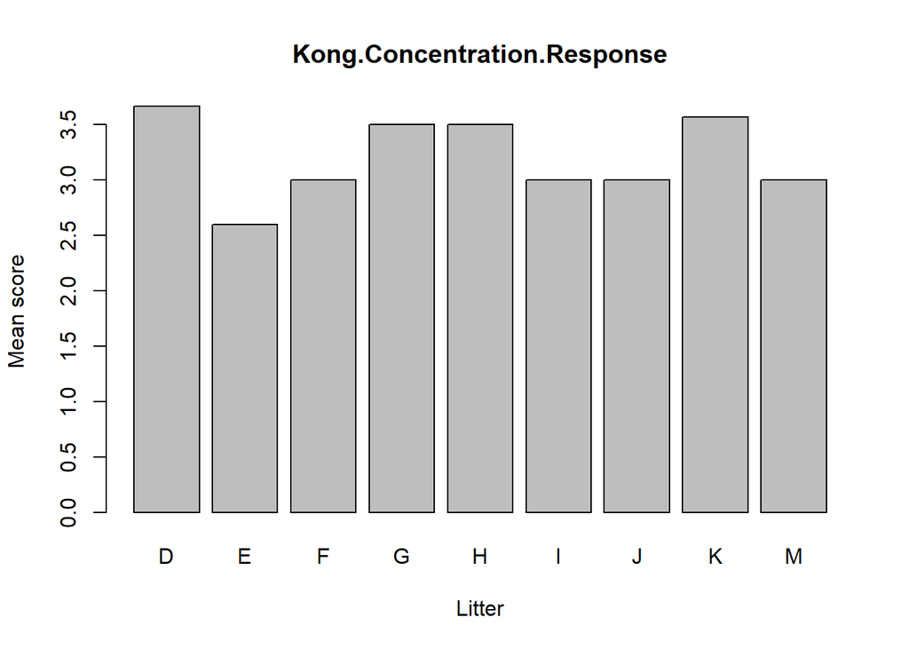

```
## [1] "Crate.Behaviours..Attention.Seeking."
```

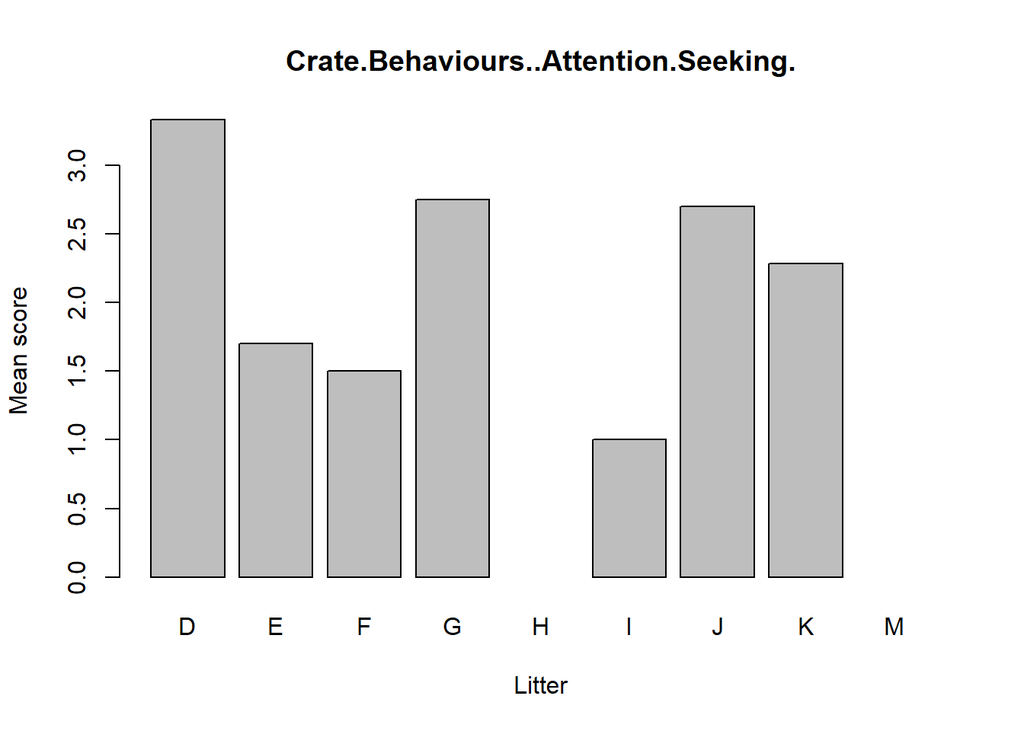

#### Count Variables

No need to perform Post Hoc because none of the variables was significantly different

```r
count_between_groups <- function(df){
  result = c()
  for (variable in count){
    r = kruskal.test(df[, variable], df$Litter)
    #print(c(variable, r[3]))
    result = rbind(result, c(variable, r[1], r[2], r[3]))
  }
  return (result)
}
dc1_count = count_between_groups(dc1)
dc2_count = count_between_groups(dc2)
dc1_count_sign = dc1_count[dc1_count[,4]<0.05, ]
dc2_count_sign = dc2_count[dc2_count[,4]<0.05, ]
```

#### Categorical Variables

Testing significance of all CATEGORICAL variables considering GROUPS

```r
categorical_between_groups <- function(df){
  result = c()
  for (variable in categorical){
    if (length(unique(df[,variable]))>1){
      r = chisq.test(df[, variable], df$Litter, simulate.p.value=TRUE)
      #print(c(variable, r[3]))
      result = rbind(result, c(variable, r[1], r[2], r[3]))
    }
  }
  return (result)
}

dc1_categorical = categorical_between_groups(dc1)
dc2_categorical = categorical_between_groups(dc2)
dc1_categorical_sign = dc1_categorical[dc1_categorical[,4]<0.05, ]
dc2_categorical_sign = dc2_categorical[dc2_categorical[,4]<0.05, ]
print(dc1_categorical_sign)
```

```
##
## [1,] "Tea.towel.Second.Response..Indifferent."
## [2,] "Tea.towel.Second.Response..Turns.head."
## [3,] "Tea.towel.Second.Response..Attempts.to.Removes.towel.with.mouth."
##      statistic parameter p.value
## [1,] 19.09418  NA        0.006996502
## [2,] 16.49987  NA        0.02798601
## [3,] 17.36498  NA        0.02098951
```

```r
print(dc2_categorical_sign)
```

```
## [[1]]
## [1] "Tea.towel.Second.Response..Indifferent."
##
## $statistic
## X-squared
##  15.42692
##
## $parameter
## df
## NA
##
## $p.value
## [1] 0.03248376
```

### Between Litters and within Data Collections

using mixed design ANOVA (AOV) even though I know the data may not be appropriate…

aov_behaviour_time <- aov(behaviour ~ litter*DC + Error(dog/DC), data= your_dataset)

```r
ordinal_within_groups <- function(df){
  r_all = c()
  r_sig = c()
  for (variable in ordinal){
    print(variable)
    r = summary(aov(df[, variable] ~ Litter*Data.Collection.Number + Error(Name/Data.Collection.Number), data = df))
    r_all = rbind(r_all, c(variable, r[[1]], r[[2]]))
    pvalues = c(unlist(r[[1]])["Pr(>F)1"],unlist(r[[2]])["Pr(>F)1"], unlist(r[[2]])["Pr(>F)2"])
    if (any(pvalues < 0.05)){
      r_sig = rbind(r_sig, c(variable, r[[1]], r[[2]]))
    }
  }
  return (r_sig)
}
ord_dcs_sig = ordinal_within_groups(dcs)
```

```
## [1] "Familiarisation.Response..Oriented.to.Handler."
```

```
## [1] "Familiarisation.Response..Exploration."
```

```
## [1] "Familiarisation.Response..Waiting."
```

```
## [1] "Call.Back.Response"
```

```
## [1] "Walking.Distractibility"
## [1] "Walking.Pull.on.leash"
## [1] "Walking.Pull.strength"
## [1] "Walking.Initiative"
## [1] "Sitting.Attempts"
## [1] "Sitting.Response"
## [1] "Lying.Attempts"
## [1] "Lying.Response"
## [1] "Lying.Settled"
## [1] "Body.check.Response"
## [1] "Distractions.First.Response..Object."
## [1] "Distractions.First.Response..Human."
## [1] "Distractions.First.Response..Car."
## [1] "Distractions.First.Response..Food."
## [1] "Distractions.Second.Response..Object."
## [1] "Distractions.Second.Response..Human."
## [1] "Distractions.Second.Response..Car."
## [1] "Distractions.Second.Response..Food."
## [1] "Distractions.Pull.on.leash"
## [1] "Distractions.Pull.strength"
## [1] "Kong.Concentration.Response"
## [1] "Kong.Retrieve.Response.to.stimulus"
## [1] "Kong.Retrieve.Response.to.assessor"
## [1] "Kong.Retrieve.Back"
## [1] "Dog.Response"
## [1] "Dog.Call.Back.Response"
## [1] "Crate.Entering"
## [1] "Crate.Behaviours..Relaxing."
```

```
## [1] "Crate.Behaviours..Sniffing.Exploring.."
```

```
## [1] "Crate.Behaviours..Attention.Seeking."
```

```
## [1] "Crate.Behaviours..Digging."
```

```
## [1] "Crate.Behaviours..Licking.Mouthing."
```

```
## [1] "Crate.Behaviours..Whining."
```

```
## [1] "Crate.Behaviours..Barking."
```

```
## [1] "Crate.Response"
```

UNDERSTAND THE OUTPUT: most of the variables result in a model with 1 factor while, some of them result in a model with 2 factors

### Visualising overall resposes in DC1 and DC2

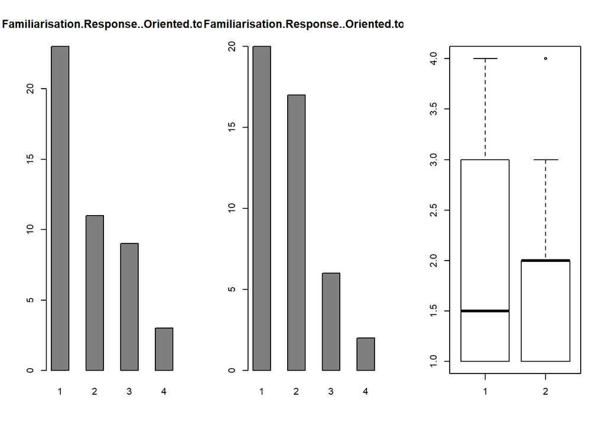

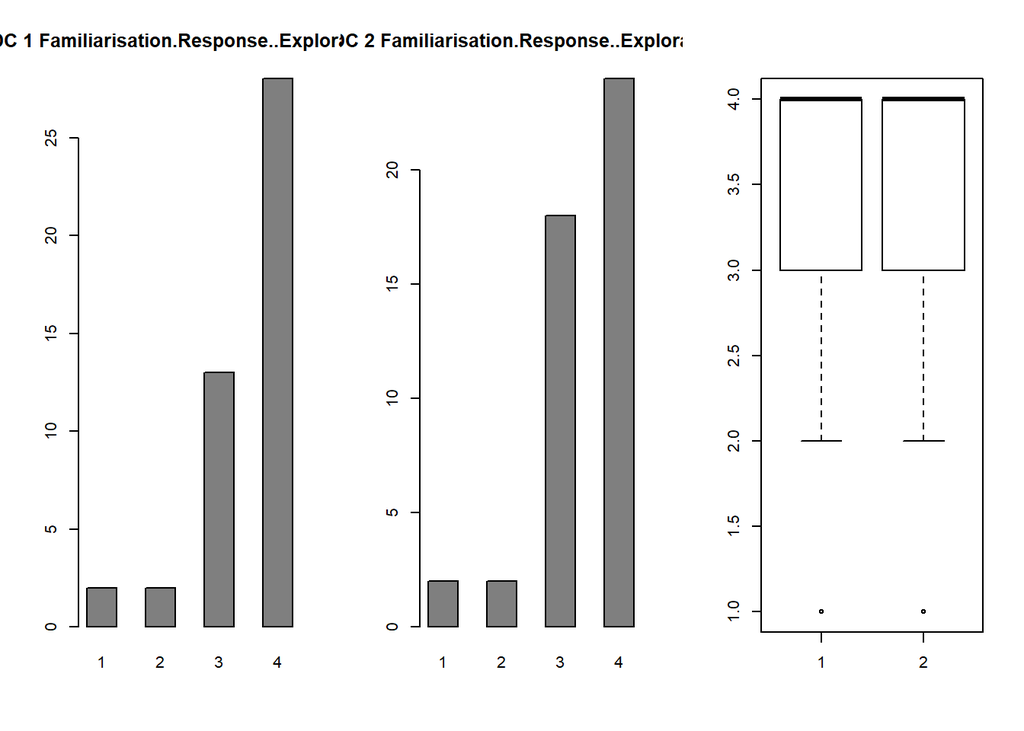

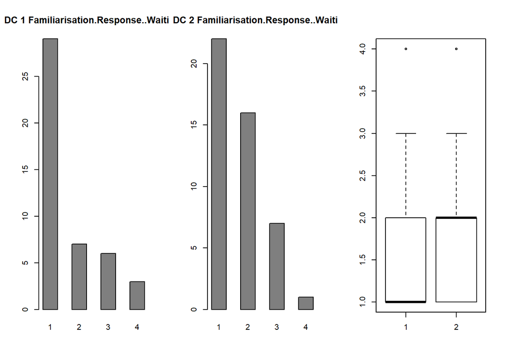

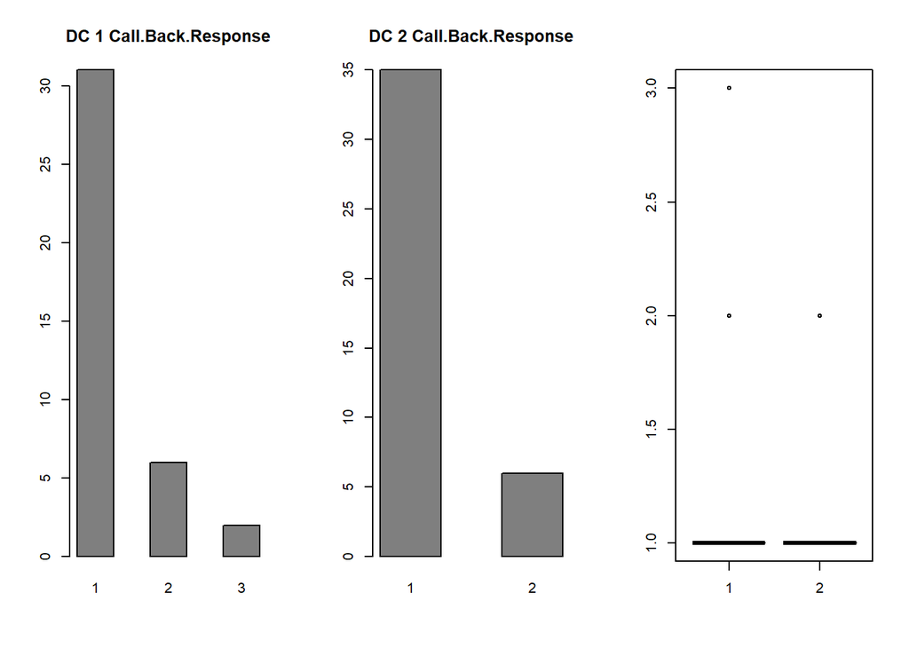

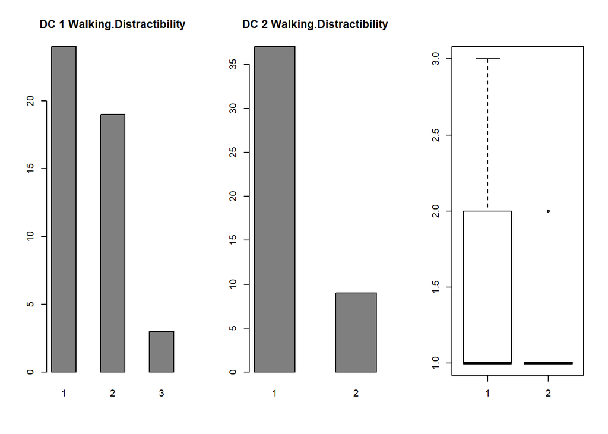

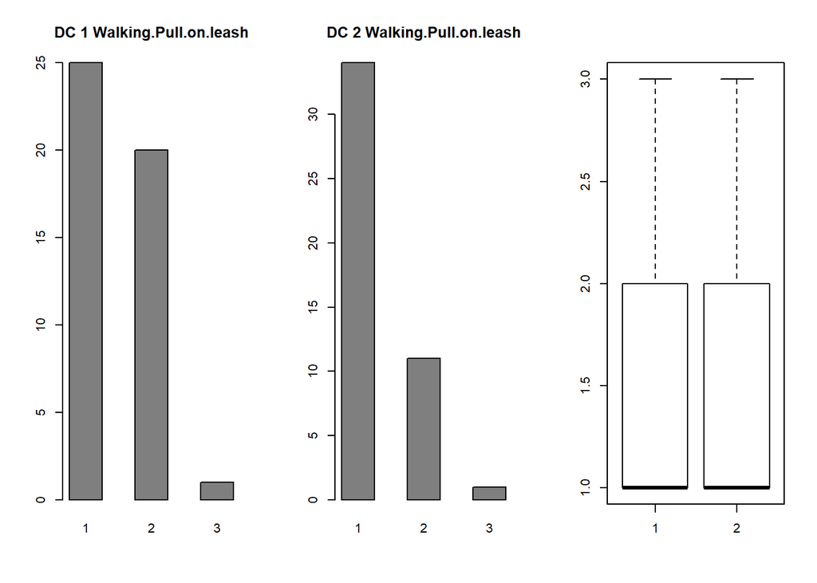

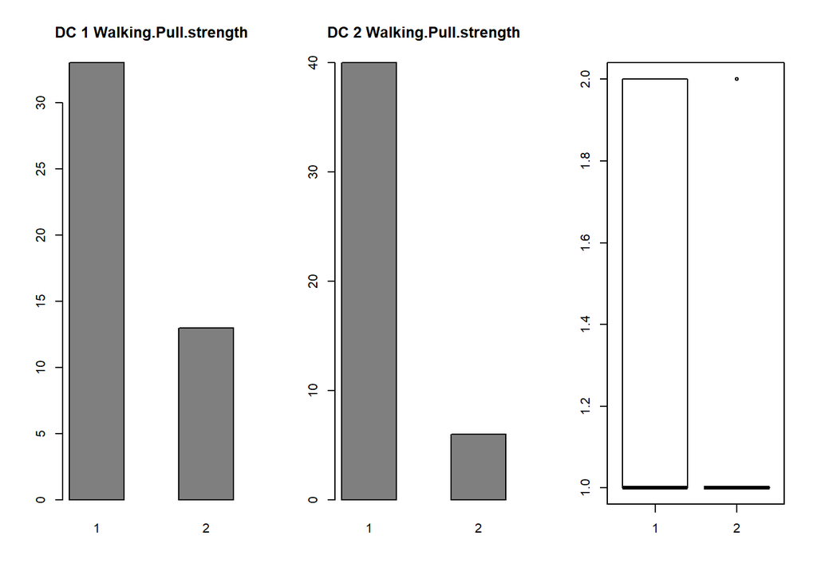

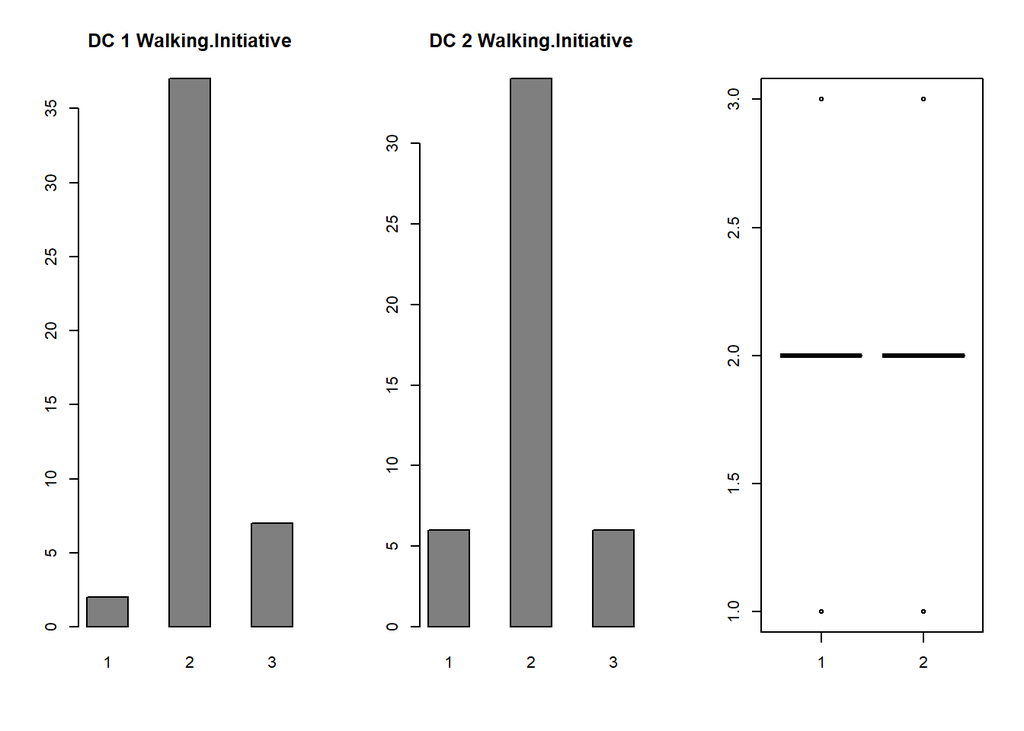

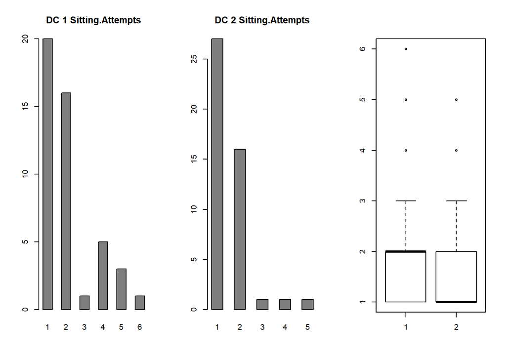

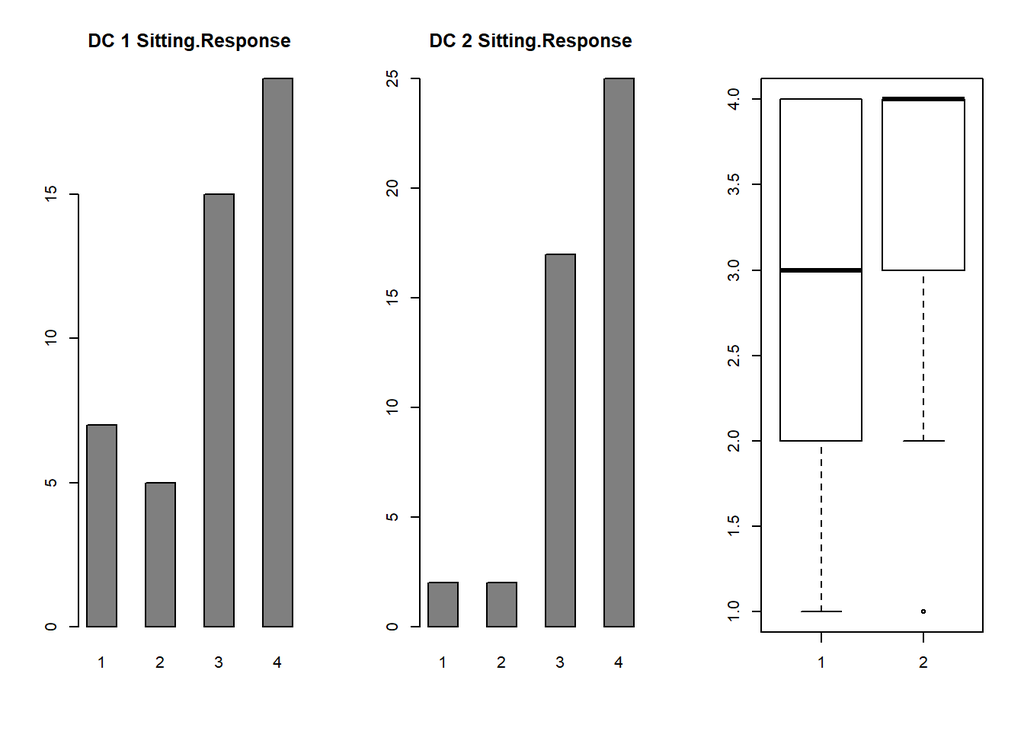

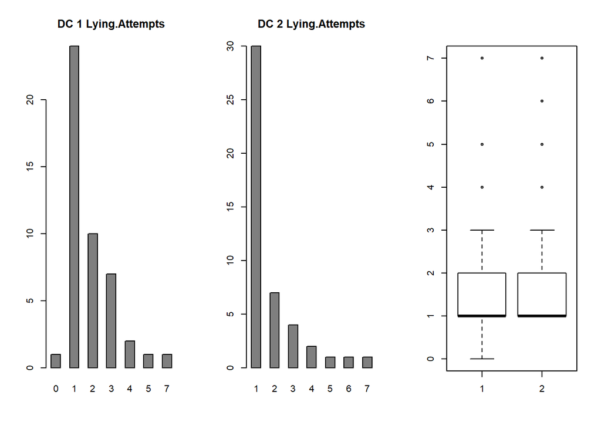

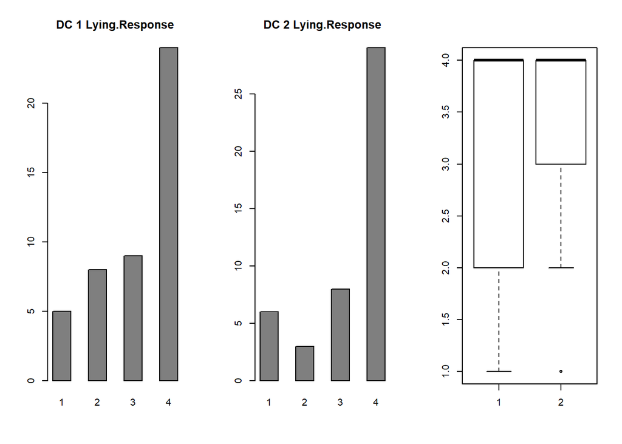

[27 more figures not shown]

```r
# barplot of behaviour per DC
for (variable in ordinal){
  par(mfrow = c(1, 3))
  for(i in unique(dcs$Data.Collection.Number)) {
    barplot(table(dcs[dcs$Data.Collection.Number == i, variable]), space = 1,
         xlab = "",
         col = "gray50",
         main = paste("DC", i, variable))
  }
  boxplot(dcs[dcs$Data.Collection.Number == 1,variable], dcs[dcs$Data.Collection.Number == 2,variable], names = unique(dcs$Data.Collection.Number))
  #title(strwrap(descriptive, width=60), cex.main=1, font.main=1)
}
```